# Practical Machine Learning Course Project

## EXPLORATORY DATA ANALYSIS: Visualizing the importance of explicative variables

In this case, for a variable to be important, I would expect the density curves to be significantly different for the 5 classes, both in terms of the height (kurtosis) and placement (skewness). However, it is not possible to eliminate any variable based on these plots.

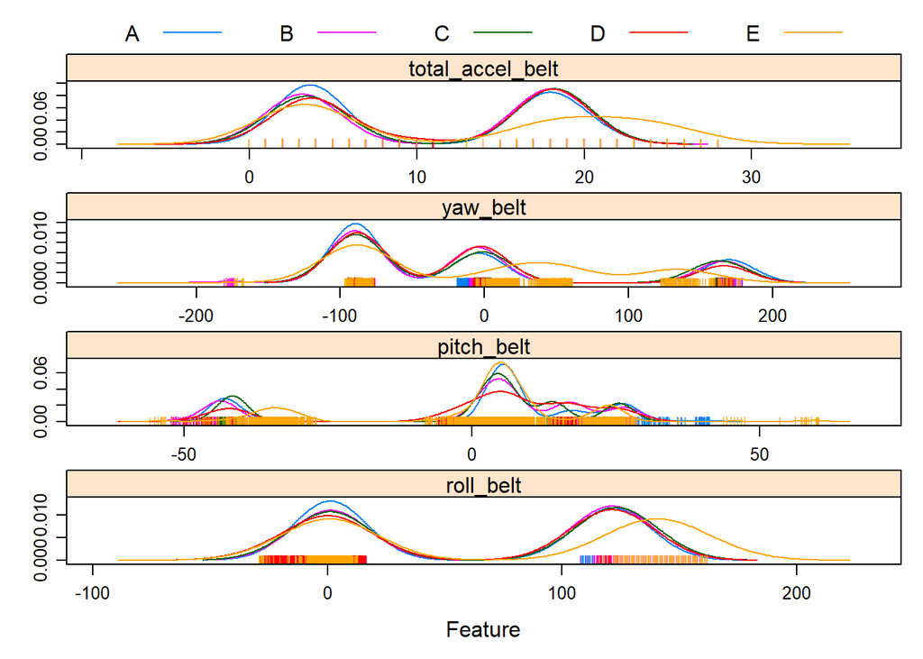

```r
beltCols <- grep("belt$", names(training), value = TRUE)
featurePlot(x = training[, beltCols[1:4]],
            y = training$classe,
            plot = "density",
            ## Pass in options to xyplot() to
            ## make it prettier
            scales = list(x = list(relation="free"),
                          y = list(relation="free")),
            adjust = 1.5,
            pch = "|",
            layout = c(1, 4),
            auto.key = list(columns = 5))
```

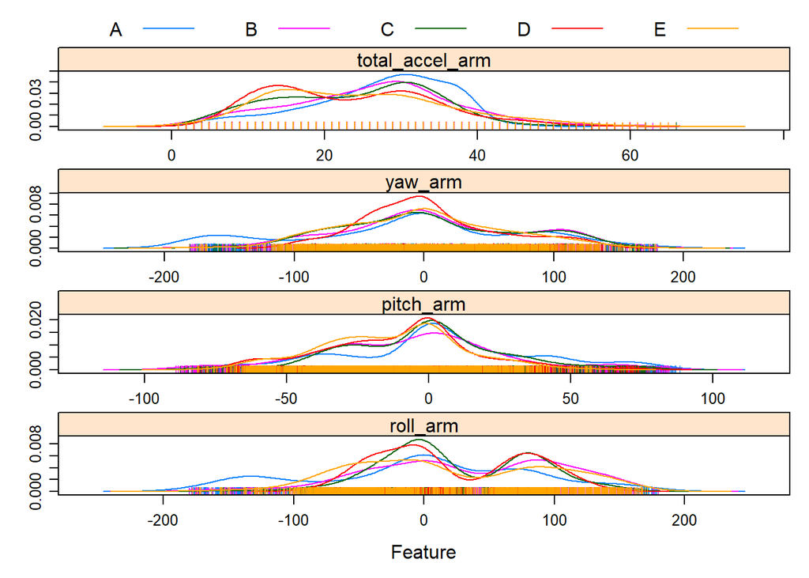

```r
#featurePlot(x=training[,c()], y= training$classe, plot="ellipse")
#featurePlot(y= training$classe, plot="ellipse")

# ARM
armCols <- grep("arm$", names(training), value = TRUE)
#transparentTheme(trans = .9)
featurePlot(x = training[, armCols[1:4]],
            y = training$classe,
            plot = "density",
            ## Pass in options to xyplot() to
            ## make it prettier
            scales = list(x = list(relation="free"),
                          y = list(relation="free")),
            adjust = 1.5,
            pch = "|",
            layout = c(1, 4),
            auto.key = list(columns = 5))
```

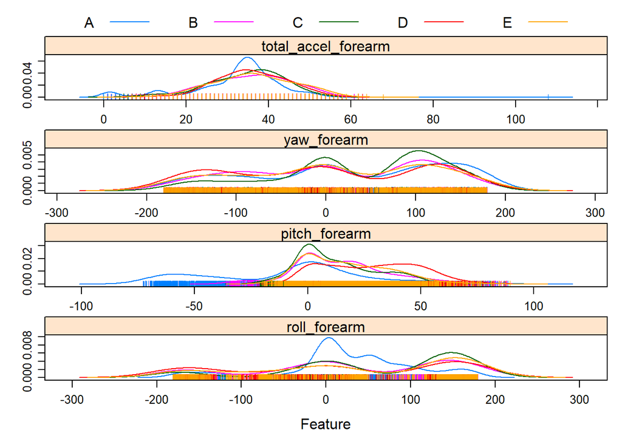

```r
# FOREARM
farmCols <- grep("forearm$", names(training), value = TRUE)
#transparentTheme(trans = .9)
featurePlot(x = training[, farmCols[1:4]],
            y = training$classe,
            plot = "density",
            ## Pass in options to xyplot() to
            ## make it prettier
            scales = list(x = list(relation="free"),
                          y = list(relation="free")),
            adjust = 1.5,
            pch = "|",
            layout = c(1, 4),
            auto.key = list(columns = 5))
```

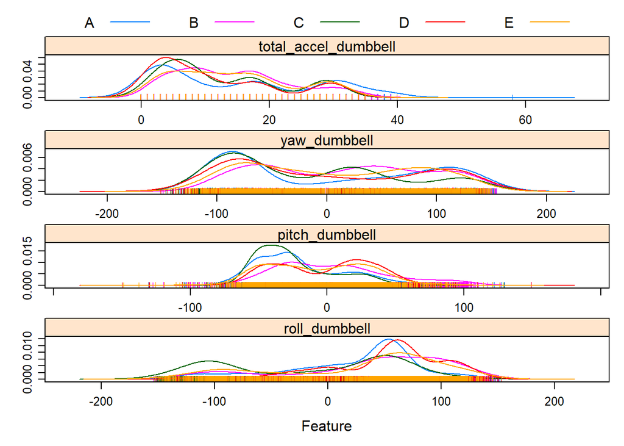

```r
# DUMBELL
dbellCols <- grep("dumbbell$", names(training), value = TRUE)
#transparentTheme(trans = .9)
featurePlot(x = training[, dbellCols[1:4]],
            y = training$classe,
            plot = "density",
            ## Pass in options to xyplot() to
            ## make it prettier
            scales = list(x = list(relation="free"),
                          y = list(relation="free")),
            adjust = 1.5,
            pch = "|",
            layout = c(1, 4),
            auto.key = list(columns = 5))
```

## MODEL SELECTION

Random Forest Model Training and OOB error reporting

```r
t.Control <- trainControl(method="cv", number = 5, allowParallel = TRUE)


fit.model.rf <- train(classe ~ ., data = training, method = "rf", trControl = t.Control, verbose = TRUE, na.action=na.omit)
fit.model.rf
```

```
## Random Forest
##
## 12757 samples
##    52 predictor
##     5 classes: 'A', 'B', 'C', 'D', 'E'
##
## No pre-processing
## Resampling: Cross-Validated (5 fold)
## Summary of sample sizes: 10205, 10205, 10206, 10207, 10205
## Resampling results across tuning parameters:
##
##   mtry  Accuracy   Kappa
##    2    0.9894962  0.9867122
##   27    0.9894963  0.9867128
##   52    0.9829902  0.9784804
##
## Accuracy was used to select the optimal model using the largest value.
## The final value used for the model was mtry = 27.
```

```r
fit.model.rf$finalModel
```

```
##
## Call:
##  randomForest(x = x, y = y, mtry = param$mtry, verbose = TRUE)
##                Type of random forest: classification
##                      Number of trees: 500
## No. of variables tried at each split: 27
##
##         OOB estimate of  error rate: 0.81%
## Confusion matrix:
##      A    B    C    D    E class.error
## A 3618    5    2    0    2 0.002481390
## B   18 2442    9    0    0 0.010935601
## C    0   15 2203    7    0 0.009887640
## D    0    2   30 2057    2 0.016260163
## E    0    1    3    7 2334 0.004690832
```

Gradient Boosting model training

```r
fit.model.gbm <- train(classe ~ ., data = training, method = "gbm", trControl = t.Control, verbose = TRUE)
fit.model.gbm
```

```
## Stochastic Gradient Boosting
##
## 12757 samples
##    52 predictor
##     5 classes: 'A', 'B', 'C', 'D', 'E'
##
## No pre-processing
## Resampling: Cross-Validated (5 fold)
## Summary of sample sizes: 10206, 10206, 10205, 10205, 10206
## Resampling results across tuning parameters:
##
##   interaction.depth  n.trees  Accuracy   Kappa
##   1                   50      0.7568396  0.6917478
##   1                  100      0.8168842  0.7681930
##   1                  150      0.8515313  0.8120949
##   2                   50      0.8501991  0.8101859
##   2                  100      0.9027979  0.8769998
##   2                  150      0.9289798  0.9101420
##   3                   50      0.8953506  0.8675631
##   3                  100      0.9430110  0.9278884
##   3                  150      0.9598648  0.9492253
##
## Tuning parameter 'shrinkage' was held constant at a value of 0.1
##
## Tuning parameter 'n.minobsinnode' was held constant at a value of 10
## Accuracy was used to select the optimal model using the largest value.
## The final values used for the model were n.trees = 150, interaction.depth =
##  3, shrinkage = 0.1 and n.minobsinnode = 10.
```

Confusion Matrixes are built after predicting the model over the testing data set. Accuracy estimates for each model will be used to decide which model predicts better.

# PREDICT

```r
predict.rf <- predict(fit.model.rf, newdata = testing)
confusionMatrix(predict.rf, testing$classe)
```

```
## Confusion Matrix and Statistics
##
##           Reference
## Prediction    A    B    C    D    E
##          A 1947    6    0    0    0
##          B    5 1308    9    1    1
##          C    0   11 1181   20    1
##          D    0    2    7 1103    2
##          E    1    1    0    1 1258
##
## Overall Statistics
##
##                Accuracy : 0.9901
##                  95% CI : (0.9875, 0.9923)
##     No Information Rate : 0.2845
##     P-Value [Acc > NIR] : < 2.2e-16
##
##                   Kappa : 0.9875
##
##  Mcnemar's Test P-Value : NA
##
## Statistics by Class:
##
##                      Class: A Class: B Class: C Class: D Class: E
## Sensitivity            0.9969   0.9849   0.9866   0.9804   0.9968
## Specificity            0.9988   0.9971   0.9944   0.9981   0.9995
## Pos Pred Value         0.9969   0.9879   0.9736   0.9901   0.9976
## Neg Pred Value         0.9988   0.9964   0.9972   0.9962   0.9993
## Prevalence             0.2845   0.1934   0.1744   0.1639   0.1838
## Detection Rate         0.2836   0.1905   0.1720   0.1607   0.1832
## Detection Prevalence   0.2845   0.1929   0.1767   0.1623   0.1837
## Balanced Accuracy      0.9979   0.9910   0.9905   0.9893   0.9981
```

```r
predict.gbm <- predict(fit.model.gbm, newdata = testing)
confusionMatrix(predict.gbm, testing$classe)
```

```
## Confusion Matrix and Statistics
##
##           Reference
## Prediction    A    B    C    D    E
##          A 1915   36    0    0    2
##          B   27 1245   42    4   12
##          C    2   44 1146   43   16
##          D    6    1    9 1064   19
##          E    3    2    0   14 1213
##
## Overall Statistics
##
##                Accuracy : 0.9589
##                  95% CI : (0.954, 0.9635)
##     No Information Rate : 0.2845
##     P-Value [Acc > NIR] : < 2.2e-16
##
##                   Kappa : 0.948
##
##  Mcnemar's Test P-Value : 1.091e-08
##
## Statistics by Class:
##
##                      Class: A Class: B Class: C Class: D Class: E
## Sensitivity            0.9805   0.9375   0.9574   0.9458   0.9612
## Specificity            0.9923   0.9846   0.9815   0.9939   0.9966
## Pos Pred Value         0.9805   0.9361   0.9161   0.9682   0.9846
## Neg Pred Value         0.9923   0.9850   0.9909   0.9894   0.9913
## Prevalence             0.2845   0.1934   0.1744   0.1639   0.1838
## Detection Rate         0.2790   0.1814   0.1669   0.1550   0.1767
## Detection Prevalence   0.2845   0.1937   0.1822   0.1601   0.1795
## Balanced Accuracy      0.9864   0.9611   0.9694   0.9698   0.9789
```

Further model comparison is performed throug the “resamples” function. This method confirms that the Random Forest model is a better predictor.

```r
# Compare model performances using resample()
models_compare <- resamples(list(RF=fit.model.rf, GradientBoosting=fit.model.gbm))

# Summary of the models performances
summary(models_compare)
```

```
##
## Call:
## summary.resamples(object = models_compare)
##
## Models: RF, GradientBoosting
## Number of resamples: 5
##
## Accuracy
##                       Min.   1st Qu.    Median      Mean   3rd Qu.      Max.
## RF               0.9870690 0.9894201 0.9894201 0.9894963 0.9898079 0.9917647
## GradientBoosting 0.9482556 0.9604077 0.9612069 0.9598648 0.9635580 0.9658957
##                  NA's
## RF                  0
## GradientBoosting    0
##
## Kappa
##                       Min.   1st Qu.    Median      Mean   3rd Qu.      Max.
## RF               0.9836408 0.9866143 0.9866162 0.9867128 0.9871089 0.9895835
## GradientBoosting 0.9345695 0.9499232 0.9509188 0.9492253 0.9538767 0.9568383
##                  NA's
## RF                  0
## GradientBoosting    0
```

Finally, we apply the random forest to the validation data.

```r
Results <- predict(fit.model.rf, newdata=validation.data.set)
Results
```

```
##  [1] B A B A A E D B A A B C B A E E A B B B
## Levels: A B C D E
```